# Linear Model: Intelligence Quotient and Pedagogical Methods

The aim is to compare the scores (p) of two pedagogical methodologies (m) as a function of the intelligence quotient (c). Perform the parameter estimation as well as the hypothesis tests to see if the parameters are significantly different from zero or not. Moreover, perform the appropriate tests to answer the following questions:

1. Can we consider that the two lines are not statistically different (M1 and M2)? **El mètode afecta a la puntuació? El coeficient de inteligència afecta a la puntuació? Els mètodes afecten de la mateixa manera, o de forma diferent, segons el coeficient de inteligència?**

```r
dd<-read.csv2("comp line.csv")

library(car)
library(emmeans)
library(tables)
#library("RcmdrMisc")
head(dd)
```

```
##   M   C  P PP
## 1 1 110 55 55
## 2 1 121 66 66
## 3 1 108 50 50
## 4 1  95 33 33
## 5 1 107 50 50
## 6 1  89 35 35
```

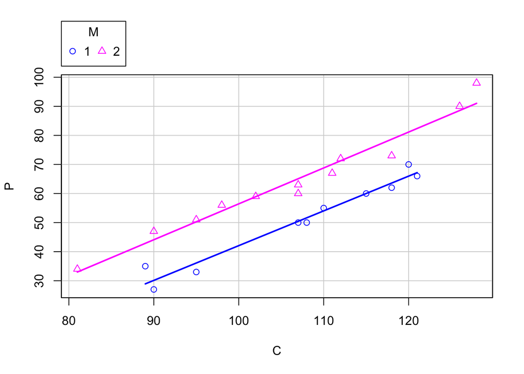

```r
dd$M<-as.factor(dd$M)
sp(P~C|M, smooth=F, dat=dd)
```

```r
summary((mP<-lm((P~M+C+M:C), dd)))
```

```
FALSE
FALSE Call:
FALSE lm(formula = (P ~ M + C + M:C), data = dd)
FALSE
FALSE Residuals:
FALSE     Min      1Q  Median      3Q     Max
FALSE -5.6767 -1.9789  0.0376  1.3367  6.9744
FALSE
FALSE Coefficients:
FALSE              Estimate Std. Error t value Pr(>|t|)
FALSE (Intercept) -77.49366   10.33232  -7.500 6.07e-07 ***
FALSE M2           10.45276   13.05628   0.801    0.434
FALSE C             1.19565    0.09575  12.487 2.65e-10 ***
FALSE M2:C          0.03924    0.12133   0.323    0.750
FALSE ---
FALSE Signif. codes:  0 '***' 0.001 '**' 0.01 '*' 0.05 '.' 0.1 ' ' 1
FALSE
FALSE Residual standard error: 3.474 on 18 degrees of freedom
FALSE Multiple R-squared:  0.966,   Adjusted R-squared:  0.9603
FALSE F-statistic: 170.4 on 3 and 18 DF,  p-value: 2.112e-13
```

```r
Anova(mP)
```

```
FALSE Anova Table (Type II tests)
FALSE
FALSE Response: P
FALSE           Sum Sq Df  F value    Pr(>F)
FALSE M         1168.3  1  96.8287 1.144e-08 ***
FALSE C         5192.8  1 430.3826 5.115e-14 ***
FALSE M:C          1.3  1   0.1046    0.7501
FALSE Residuals  217.2 18
FALSE ---
FALSE Signif. codes:  0 '***' 0.001 '**' 0.01 '*' 0.05 '.' 0.1 ' ' 1
```

2. Can the two lines be considered parallel lines?
3. Can the two intercepts be considered not statistically different?
4. For each one of the following values of intelligence quotient c: 90, 105 y 120, which differences do exists in the scores for each one of the methodologies?

```r
(emm<-emmeans(mP,~M|C, at=list(C=c(90, 105, 120))))
```

```
## C =  90:
##  M   emmean       SE df lower.CL upper.CL
##  1 30.11519 1.987551 18 25.93950 34.29088
##  2 44.09963 1.572317 18 40.79631 47.40294
##
## C = 105:
##  M   emmean       SE df lower.CL upper.CL
##  1 48.05000 1.120293 18 45.69635 50.40365
##  2 62.62305 1.007048 18 60.50732 64.73878
##
## C = 120:
##  M   emmean       SE df lower.CL upper.CL
##  1 65.98480 1.638663 18 62.54210 69.42751
##  2 81.14647 1.433736 18 78.13430 84.15864
##
## Results are given on the : (not the response) scale.
## Confidence level used: 0.95
```

```r
CLD(emm,Letters=letters, reversed=T)
```

```
## C =  90:
##  M   emmean       SE df lower.CL upper.CL .group
##  2 44.09963 1.572317 18 40.79631 47.40294  a
##  1 30.11519 1.987551 18 25.93950 34.29088   b
##
## C = 105:
##  M   emmean       SE df lower.CL upper.CL .group
##  2 62.62305 1.007048 18 60.50732 64.73878  a
##  1 48.05000 1.120293 18 45.69635 50.40365   b
##
## C = 120:
##  M   emmean       SE df lower.CL upper.CL .group
##  2 81.14647 1.433736 18 78.13430 84.15864  a
##  1 65.98480 1.638663 18 62.54210 69.42751   b
##
## Results are given on the : (not the response) scale.
## Confidence level used: 0.95
## significance level used: alpha = 0.05
```

```r
pairs(emm)
```

```
## C =  90:
##  contrast  estimate       SE df t.ratio p.value
##  1 - 2    -13.98444 2.534273 18  -5.518  <.0001
##
## C = 105:
##  contrast  estimate       SE df t.ratio p.value
##  1 - 2    -14.57305 1.506387 18  -9.674  <.0001
##
## C = 120:
##  contrast  estimate       SE df t.ratio p.value
##  1 - 2    -15.16167 2.177342 18  -6.963  <.0001
```

Son clarament diferents a 90, 105 i 120. Almenys en aquest rang (90-120).

Podem demanar quins son els pendents?

```r
(emmp<-emtrends(mP,~M, var="C"))
```

```
##  M  C.trend         SE df  lower.CL upper.CL
##  1 1.195654 0.09574806 18 0.9944946 1.396813
##  2 1.234895 0.07452801 18 1.0783171 1.391472
##
## Trends are based on the : (transformed) scale
## Confidence level used: 0.95
```

```r
pairs(emmp)
```

```
##  contrast    estimate        SE df t.ratio p.value
##  1 - 2    -0.03924087 0.1213347 18  -0.323  0.7501
```

Model additiu:

```r
summary((mP2<-lm((P~M+C), dd)))
```

```
FALSE
FALSE Call:
FALSE lm(formula = (P ~ M + C), data = dd)
FALSE
FALSE Residuals:
FALSE    Min     1Q Median     3Q    Max
FALSE -5.503 -2.025 -0.088  1.529  7.296
FALSE
FALSE Coefficients:
FALSE              Estimate Std. Error t value Pr(>|t|)
FALSE (Intercept) -80.11563    6.25264  -12.81 8.50e-11 ***
FALSE M2           14.64776    1.45307   10.08 4.62e-09 ***
FALSE C             1.22009    0.05741   21.25 1.05e-14 ***
FALSE ---
FALSE Signif. codes:  0 '***' 0.001 '**' 0.01 '*' 0.05 '.' 0.1 ' ' 1
FALSE
FALSE Residual standard error: 3.391 on 19 degrees of freedom
FALSE Multiple R-squared:  0.9658,  Adjusted R-squared:  0.9622
FALSE F-statistic: 268.2 on 2 and 19 DF,  p-value: 1.186e-14
```

```r
Anova(mP2)
```

```
FALSE Anova Table (Type II tests)
FALSE
FALSE Response: P
FALSE           Sum Sq Df F value    Pr(>F)
FALSE M         1168.3  1  101.62 4.624e-09 ***
FALSE C         5192.8  1  451.67 1.053e-14 ***
FALSE Residuals  218.4 19
FALSE ---
FALSE Signif. codes:  0 '***' 0.001 '**' 0.01 '*' 0.05 '.' 0.1 ' ' 1
```

```r
(emm<-emmeans(mP,~M|C))
```

```
## C = 106.7273:
##  M   emmean       SE df lower.CL upper.CL
##  1 50.11522 1.099803 18 47.80462 52.42582
##  2 64.75605 1.003360 18 62.64807 66.86403
##
## Results are given on the : (not the response) scale.
## Confidence level used: 0.95
```

fa la comapracio nomes en un punt, perque es la mitjana en totes les Cs. si veolm el pendent, ja esle teiem en el summary (C Estimate).

```r
summary((mPP<-lm((PP~M+C+M:C), dd)))
```

```
FALSE
FALSE Call:
FALSE lm(formula = (PP ~ M + C + M:C), data = dd)
FALSE
FALSE Residuals:
FALSE     Min      1Q  Median      3Q     Max
FALSE -4.7524 -1.7235 -0.1493  1.9500  6.0805
FALSE
FALSE Coefficients:
FALSE              Estimate Std. Error t value Pr(>|t|)
FALSE (Intercept) -77.49366    9.15403  -8.466 1.09e-07 ***
FALSE M2          -69.20305   11.56736  -5.983 1.17e-05 ***
FALSE C             1.19565    0.08483  14.095 3.64e-11 ***
FALSE M2:C          0.69639    0.10750   6.478 4.30e-06 ***
FALSE ---
FALSE Signif. codes:  0 '***' 0.001 '**' 0.01 '*' 0.05 '.' 0.1 ' ' 1
FALSE
FALSE Residual standard error: 3.077 on 18 degrees of freedom
FALSE Multiple R-squared:  0.9828,  Adjusted R-squared:  0.9799
FALSE F-statistic: 342.3 on 3 and 18 DF,  p-value: 4.669e-16
```

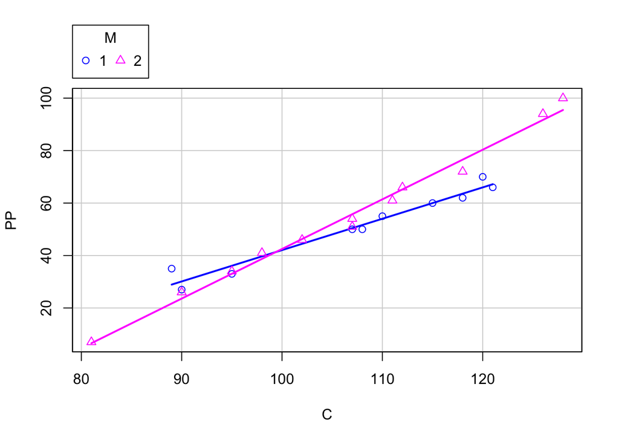

```r
sp(PP~C|M, smooth=F, dat=dd)
```

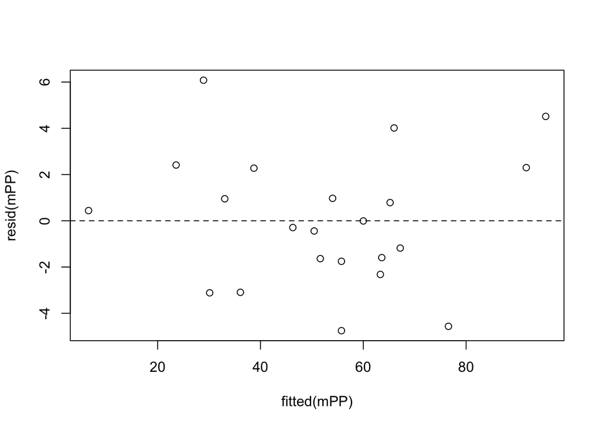

```r
plot(fitted(mPP), resid(mPP))
abline(h=0, lty=2)
```

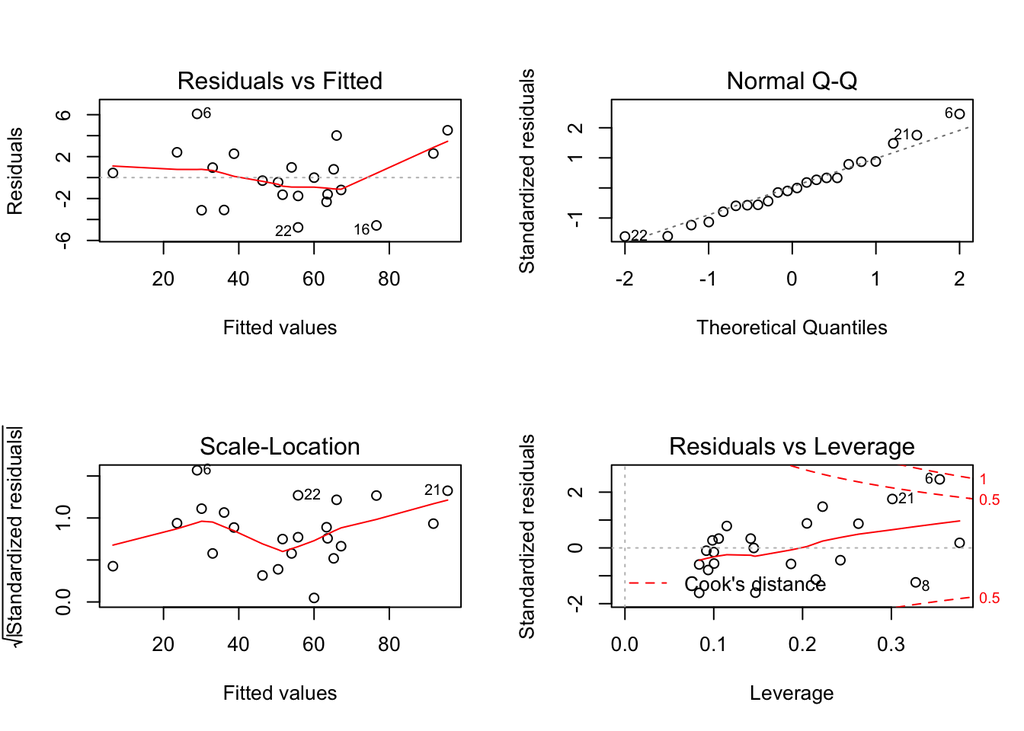

```r
oldpar<-par(mfrow=c(2,2))
plot(mPP, ask=F)
```

```r
par(oldpar)
```

```r
Anova(mPP)
```

```
FALSE Anova Table (Type II tests)
FALSE
FALSE Response: PP
FALSE           Sum Sq Df F value    Pr(>F)
FALSE M          149.7  1  15.812 0.0008852 ***
FALSE C         9260.3  1 977.798 < 2.2e-16 ***
FALSE M:C        397.5  1  41.967 4.296e-06 ***
FALSE Residuals  170.5 18
FALSE ---
FALSE Signif. codes:  0 '***' 0.001 '**' 0.01 '*' 0.05 '.' 0.1 ' ' 1
```

```r
(emmPP<-emmeans(mPP,~M|C, at=list(C=c(90, 100, 110, 120, 130))))
```

```
FALSE C =  90:
FALSE  M   emmean        SE df lower.CL  upper.CL
FALSE  1 30.11519 1.7608920 18 26.41569  33.81469
FALSE  2 23.58756 1.3930114 18 20.66095  26.51417
FALSE
FALSE C = 100:
FALSE  M   emmean        SE df lower.CL  upper.CL
FALSE  1 42.07173 1.1534876 18 39.64834  44.49511
FALSE  2 42.50804 0.9795522 18 40.45007  44.56600
FALSE
FALSE C = 110:
FALSE  M   emmean        SE df lower.CL  upper.CL
FALSE  1 54.02827 0.9997596 18 51.92785  56.12868
FALSE  2 61.42851 0.9222403 18 59.49096  63.36607
FALSE
FALSE C = 120:
FALSE  M   emmean        SE df lower.CL  upper.CL
FALSE  1 65.98480 1.4517912 18 62.93470  69.03490
FALSE  2 80.34899 1.2702341 18 77.68032  83.01765
FALSE
FALSE C = 130:
FALSE  M   emmean        SE df lower.CL  upper.CL
FALSE  1 77.94134 2.1575608 18 73.40847  82.47421
FALSE  2 99.26946 1.8023388 18 95.48289 103.05603
FALSE
FALSE Results are given on the : (not the response) scale.
FALSE Confidence level used: 0.95
```

```r
pairs(emmPP)
```

```
FALSE C =  90:
FALSE  contrast    estimate       SE df t.ratio p.value
FALSE  1 - 2      6.5276260 2.245266 18   2.907  0.0094
FALSE
FALSE C = 100:
FALSE  contrast    estimate       SE df t.ratio p.value
FALSE  1 - 2     -0.4363099 1.513293 18  -0.288  0.7764
FALSE
FALSE C = 110:
FALSE  contrast    estimate       SE df t.ratio p.value
FALSE  1 - 2     -7.4002458 1.360164 18  -5.441  <.0001
FALSE
FALSE C = 120:
FALSE  contrast    estimate       SE df t.ratio p.value
FALSE  1 - 2    -14.3641817 1.929039 18  -7.446  <.0001
FALSE
FALSE C = 130:
FALSE  contrast    estimate       SE df t.ratio p.value
FALSE  1 - 2    -21.3281176 2.811315 18  -7.587  <.0001
```

```r
(emmPPt<-emtrends(mPP,~M, var="C"))
```

```
FALSE  M  C.trend         SE df lower.CL upper.CL
FALSE  1 1.195654 0.08482902 18 1.017435 1.373873
FALSE  2 1.892047 0.06602889 18 1.753326 2.030769
FALSE
FALSE Trends are based on the : (transformed) scale
FALSE Confidence level used: 0.95
```